# Modelo para detección de trauma abdominal con imagénes radiográficas empleando Redes Convolucionales

### Experimentación con distintas arquitecturas de Redes Neuronales Convolucionales tanto diseñadas desde cero como aplicando técnicas de transfer learning

### Desarrollo de competencia Kaggle: RSNA 2023 Abdominal Trauma Detection

### https://www.kaggle.com/competitions/rsna-2023-abdominal-trauma-detection/overview

### **Problema a resolver**: Desarrollo de modelo de AI que permita identificar a través de imágenes radiográficas si un paciente presente o no un trauma abdominal en etapa temprana

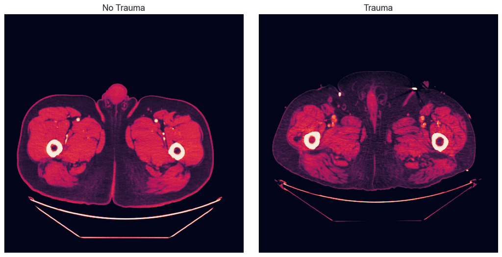

**Context**: Blunt force abdominal trauma is among the most common types of traumatic injury, with the most frequent cause being motor vehicle accidents. Abdominal trauma may result in damage and internal bleeding of the internal organs, including the liver, spleen, kidneys, and bowel. Detection and classification of injuries are key to effective treatment and favorable outcomes. A large proportion of patients with abdominal trauma require urgent surgery. Abdominal trauma often cannot be diagnosed clinically by physical exam, patient symptoms, or laboratory tests.

Importación de librerías

```python
# Operating System and File Management
import os
import shutil

# Medical Imaging
import pydicom
from PIL import Image

# Data Manipulation and Analysis
import pandas as pd
import numpy as np

# Machine Learning (PyTorch)
import torch
import torch.nn as nn
from torch.utils.data import Dataset, DataLoader
import torch.optim as optim
import torch.nn.functional as F
from torch.cuda.amp import autocast, GradScaler

# Computer Vision (PyTorch)
import torchvision
from torchvision import transforms

# Data Splitting and Evaluation
from sklearn.metrics import confusion_matrix
from sklearn.model_selection import train_test_split

# Hyperparameter Tuning
import optuna
from optuna.trial import TrialState
from optuna.integration import SkoptSampler

# Data Visualization
import matplotlib.pyplot as plt
import seaborn as sns
from torch.utils.tensorboard import SummaryWriter

# Other
from ipywidgets import FileUpload, Output
import json
```

## Procesamiento de datos

### Descarga de datos del repositorio de la competencia Kaggle

El siguiente código se encarga de descargar en un archivo comprimido el set de datos de Kaggle utilizando la API de la competencia: kaggle competitions download -c rsna-2023-abdominal-trauma-detection

```python
current_path = os.getcwd()
kaggle_json_path = os.path.join(current_path, "kaggle.json")

with open(kaggle_json_path) as f:
    kaggle_json_data = json.load(f)

os.environ["KAGGLE_USERNAME"] = kaggle_json_data["username"]
os.environ["KAGGLE_KEY"] = kaggle_json_data["key"]


def unzip_files():
    zip_file_path = "rsna-2023-abdominal-trauma-detection.zip"
    destination_folder = "images_dcm"
    shutil.unpack_archive(zip_file_path, destination_folder)
    return None

def main():
    !kaggle competitions download -c rsna-2023-abdominal-trauma-detection
    unzip_files()
    return None

if __name__ == "__main__":
    main()
```

### Conversión de radiografías a formato PNG

Las imagénes médicas son descargadas en su formato original dicom (Digital Imaging and Communications in Medicine), por lo que para su procesamiento se deben pasar a un formato como .jpg o .png para aplicar las técnicas de ingeniería de imágenes y modelos de AI. El siguiente código convierte todas las imagenes descargadas en formato .dcm a un formato .png

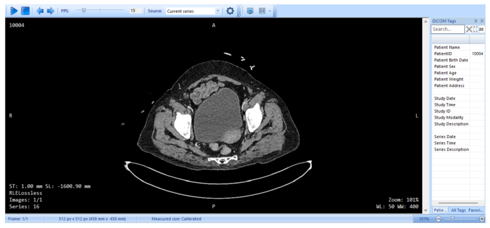

```python
def convertir_dicom_a_png(dir_dicom, dir_png):
    if not os.path.exists(carpetadir_png):
        os.makedirs(carpetadir_png)

    archivos_dicom = [archivo for archivo in os.listdir(carpetadir_dicom) if archivo.endswith('.dcm')]

    for archivo in archivos_dicom:
        ruta_dicom = os.path.join(carpetadir_dicom, archivo)
        ds = pydicom.dcmread(ruta_dicom)
        nombre_png = archivo.replace('.dcm', '.png')
        ruta_png = os.path.join(carpetadir_png, nombre_png)
        plt.imsave(ruta_png, ds.pixel_array, cmap=plt.cm.bone)

carpetadir_dicom = 'images_dcm'  # Carpeta que contiene archivos DICOM
carpetadir_png = 'images_png'  # Carpeta de salida para las imágenes PNG
convertir_dicom_a_png(carpetadir_dicom, carpetadir_png)
```

### Depuración de imagenes duplicadas

El siguiente código genera un repositorio con imágenes únicas, ya que muchas de las imágenes oringales se encuentran repetidas desde el repertorio original

```python
directorio_imagenes = "images_png"
directorio_destino = "images_uniques"

if not os.path.exists(directorio_destino):
    os.makedirs(directorio_destino)

ids_vistos = {}

for filename in os.listdir(directorio_imagenes):
    if filename.endswith(".png"):
        id_hash = filename.split("_")[0]

        if id_hash not in ids_vistos:
            nuevo_nombre = f"{id_hash}.png"
            shutil.copy(os.path.join(directorio_imagenes, filename), os.path.join(directorio_destino, nuevo_nombre))
            ids_vistos[id_hash] = True
        else:
            os.remove(os.path.join(directorio_imagenes, filename))
```

### Construcción del set de datos con la etiqueta de la imagen

El siguiente código reparte las imagenes en dos repositorios, uno con imagenes que presenta un trauma (label 1) y otro con las imagenes que no presentan trauma (label 0), esto se realiza haciendo uso del csv 'target.csv', también descargado del repositorio de la competencia, el cual contiene los id de las imagenes con su respectiva etiquet

```python
image_folder = 'images_uniques'
folder_images_1 = 'images_1'
folder_images_0 = 'images_0'

csv_path = 'target.csv'
df = pd.read_csv(csv_path)

for index, row in df.iterrows():
    image_id = row['patient_id']
    target = row['any_injury']

    if target == 1:
        imagen_origen = os.path.join(image_folder, f'{image_id}.png')
        imagen_destino = os.path.join(folder_images_1, f'{image_id}.png')
        shutil.copy(imagen_origen, imagen_destino)
    else:
        imagen_origen = os.path.join(image_folder, f'{image_id}.png')
        imagen_destino = os.path.join(folder_images_0, f'{image_id}.png')
        shutil.copy(imagen_origen, imagen_destino)
```

### Data Augmentation

El set de datos tiene un alto desbalanceo de clases, el 72,8% de las imagenes son de radiografías sin traumas y el 27,2% restante son imagenes con trauma.

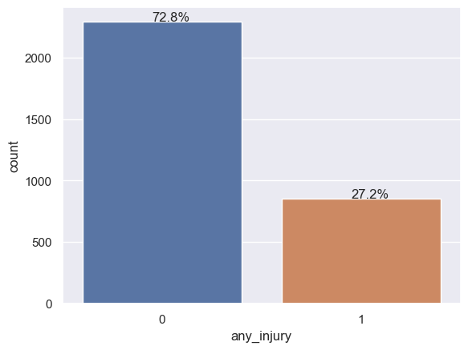

```python
target_df = pd.read_csv('target/train.csv')
target_df['any_injury'].value_counts()
sns.set_theme(style="darkgrid")
ax = sns.countplot(x="any_injury", data=target_df)
total = len(target_df['any_injury'])
for p in ax.patches:
    percentage = '{:.1f}%'.format(100 * p.get_height()/total)
    x = p.get_x() + p.get_width() / 2 - 0.05
    y = p.get_y() + p.get_height() + 5
    ax.annotate(percentage, (x, y))
```

Con el objetivo de resolver el problema del desbalanceo de clases, se realiza un data augmentation generando el triple de imágenes pertenecientes a la clase 1 (imagenes con trauma). Para el data augmentation se utilizan dos técnicas: flip (voltear la imagen) y rotation 180 (rotación de 180 grados de la imagen)

```python
original_folder = 'images_1'
augmented_folder = 'augmented_images'
if not os.path.exists(augmented_folder):
    os.mkdir(augmented_folder)

image_files = [f for f in os.listdir(original_folder) if f.endswith('.png')]


for img_file in image_files:
    img_path = os.path.join(original_folder, img_file)
    img = Image.open(img_path)

    img.save(os.path.join(augmented_folder, img_file.split('.')[0] + '_original.png'))

    # Flip
    flipped_img = img.transpose(Image.FLIP_LEFT_RIGHT)
    flipped_img.save(os.path.join(augmented_folder, img_file.split('.')[0] + '_flipped.png'))

    # Rotation
    rotated_img = img.rotate(180)
    rotated_img.save(os.path.join(augmented_folder, img_file.split('.')[0] + '_rotated_90.png'))

print("Data augmentation complete.")
```

Ejemplo del resultado del data augmentation de la imagen original Imagen original, Imagen volteada, Imagen rotada 180

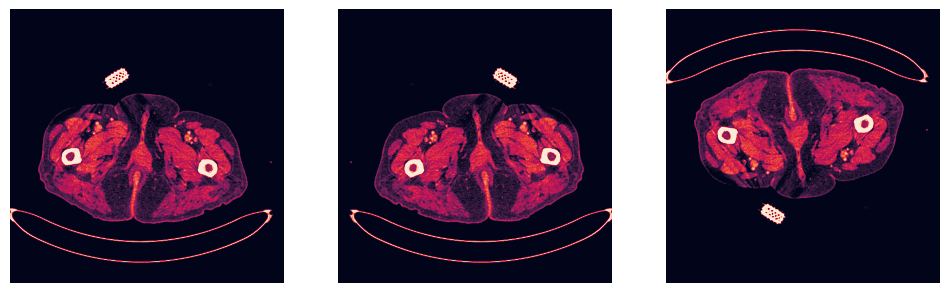

```python
sample_images = [f for f in os.listdir(augmented_folder) if f.endswith('.png')]
sample_images = sample_images[:3]
plt.figure(figsize=(12,12))
for i in range(0, len(sample_images)):
    plt.subplot(1, 3, i+1)
    image = Image.open(os.path.join(augmented_folder, sample_images[i]))
    plt.imshow(image)
    plt.axis('off')
```

El siguiente código genera el conjunto de datos final, el cual contiene todas las imagenes con su respectiva etiqueta

```python
directorio_imagenes_1 = "augmented_images"
directorio_imagenes_0 = "images_0"

archivos_1 = os.listdir(directorio_imagenes_1)
archivos_0 = os.listdir(directorio_imagenes_0)

data = [(os.path.join(directorio_imagenes_1, nombre), 1) for nombre in archivos_1] + \
       [(os.path.join(directorio_imagenes_0, nombre), 0) for nombre in archivos_0]
```

## Ingeniería de imagenes

La variable transform es una variable que contiene una secuencia de métodos del objeto transforms de Pytorch para hacer ingeniería de imágenes, en este caso la imagen origial pasa por las siguientes transformaciones:

```python
transform = transforms.Compose([
    transforms.Grayscale(num_output_channels=1),
    transforms.Resize((128, 128)),
    transforms.ToTensor(),
    transforms.Normalize(mean=0., std=1.)
])
```

El dispositivo utilizado para el procesamiento de los datos y de las redes neuronales que se entrenarán es cuda aprovechando la ventaja de las GPU para el procesamiento en paralelo

```python
device = torch.device("cuda" if torch.cuda.is_available() else "cpu")
device
```

```
device(type='cuda')
```

La siguiente clase CustomDataset contiene los métodos de construcción de los data loader tanto para los datos de entrenamiento como para los datos de validación. Los Data Loader generarán baches de 32 valores (tensores con su etiqueta)

```python
class CustomDataset(Dataset):
    def __init__(self, data, transform=None):
        self.data = data
        self.transform = transform

    def __len__(self):
        return len(self.data)

    def __getitem__(self, idx):
        img_name, label = self.data[idx]

        if os.path.exists(img_name):
            image = Image.open(img_name)
            label = torch.tensor(label, dtype=torch.float32)

            if self.transform:
                image = self.transform(image)

            return image, label
        else:
            return None, None

data_train, data_test = train_test_split(data, test_size=0.15, random_state=42, stratify=[label for _, label in data])

train_dataset = CustomDataset(data_train, transform=transform)
test_dataset = CustomDataset(data_test, transform=transform)

batch_size = 32

train_loader = DataLoader(train_dataset, batch_size=batch_size, shuffle=True)
test_loader = DataLoader(test_dataset, batch_size=batch_size, shuffle=False)
```

## Red Neuronal Convolucional

### Optimización de Hiper parámetros

La clase Net es la estructura de la red neuronal convolucional con hiperparámetros variables, los cuales son los que serán tuneados a través de la librería Optuna para encontrar la configuración óptima entre número de capas convolucionales, número de neuronas de las capas ocultas, tamaño de los filtros, optimizador, y learning rate

```python
class Net(nn.Module):
    def __init__(self, trial, num_conv_layers, num_filters, num_neurons, drop_conv2, drop_fc1):
        super(Net, self).__init__()
        in_size = 256
        kernel_size = 3

        self.convs = nn.ModuleList([nn.Conv2d(1, num_filters[0], kernel_size=(3, 3))])
        out_size = in_size - kernel_size + 1
        out_size = int(out_size / 2)
        for i in range(1, num_conv_layers):
            self.convs.append(nn.Conv2d(in_channels=num_filters[i-1], out_channels=num_filters[i], kernel_size=(3, 3)))
            out_size = out_size - kernel_size + 1
            out_size = int(out_size/2)

        self.conv2_drop = nn.Dropout2d(p=drop_conv2)
        self.out_feature = num_filters[num_conv_layers-1] * out_size * out_size
        self.fc1 = nn.Linear(self.out_feature, num_neurons)
        self.fc2 = nn.Linear(num_neurons, 1)
        self.p1 = drop_fc1

        for i in range(1, num_conv_layers):
            nn.init.kaiming_normal_(self.convs[i].weight, nonlinearity='relu')
            if self.convs[i].bias is not None:
                nn.init.constant_(self.convs[i].bias, 0)
        nn.init.kaiming_normal_(self.fc1.weight, nonlinearity='relu')

    def forward(self, x):
        for i, conv_i in enumerate(self.convs):
            if i == 2:
                x = F.relu(F.max_pool2d(self.conv2_drop(conv_i(x)), 2))
            else:
                x = F.relu(F.max_pool2d(conv_i(x), 2))

        x = x.view(x.size(0), -1)
        x = F.relu(self.fc1(x))
        x = F.dropout(x, p=self.p1, training=self.training)
        x = F.sigmoid(self.fc2(x))
        return x

#La función de pérdida es Binary Cross Entropy al ser una tarea de clasificación binaria
criterio = nn.BCEWithLogitsLoss()
os.environ["CUDA_LAUNCH_BLOCKING"] = "1"
```

Las siguientes son las funciones de entrenamiento y testeo de la CNN la cual utiliza el método GradScaler escalar los parámetros de la NN y agilizar así el entrenamiento.

```python
def train(model, optimizer):
    epochs = 10
    scaler = GradScaler()
    for epoch in range(epochs):
        model.train()
        total_loss = 0.0

        for images, labels in train_loader:
            images, labels = images.to(device), labels.to(device)
            optimizer.zero_grad()

            with autocast():
                outputs = model(images)
                loss = criterio(outputs, labels.unsqueeze(1))

            scaler.scale(loss).backward()
            scaler.step(optimizer)
            scaler.update()
```

```python
def test(network):
    network.eval()
    correct = 0
    with torch.no_grad(), autocast():
        for images, labels in test_loader:
            images, labels = images.to(device), labels.to(device)
            outputs = network(images)
            predicted = torch.round(torch.sigmoid(outputs))
            correct += (predicted == labels.unsqueeze(1)).sum().item()

    accuracy_test = correct / len(test_loader.dataset)

    return accuracy_test
```

La función objective es la encargada de realizar los ensayos con las distintas combinaciones de hiperparámetros para encontrar la mejor combinación, también se aprovecha el método de importance de la libería optuna para identificar los hiperparámetros con más relevancia sobre la función de error. La estructura de CNN que mejor rendimiento presente durante todos los ensayos se guardarán en un archivo csv llamado optuna_results.csv.

```python
def objective(trial):
    num_conv_layers = trial.suggest_int("num_conv_layers", 2, 3)
    num_filters = [int(trial.suggest_discrete_uniform("num_filter_"+str(i), 16, 128, 16))
                   for i in range(num_conv_layers)]
    num_neurons = trial.suggest_int("num_neurons", 10, 260, 10)
    drop_conv2 = trial.suggest_float("drop_conv2", 0.2, 0.5)
    drop_fc1 = trial.suggest_float("drop_fc1", 0.2, 0.5)

    model = Net(trial, num_conv_layers, num_filters, num_neurons, drop_conv2,  drop_fc1).to(device)

    optimizer_name = trial.suggest_categorical("optimizer", ["Adam"])
    lr = trial.suggest_float("lr", 1e-5, 1e-2, log=True)
    optimizer = getattr(optim, optimizer_name)(model.parameters(), lr=lr)

    epochs = 10
    train(model, optimizer)
    accuracy = test(model)

    trial.report(accuracy, epochs)
    if trial.should_prune():
        raise optuna.exceptions.TrialPruned()

    return accuracy

if __name__ == '__main__':

    n_epochs = 12
    batch_size_train = 32
    batch_size_test = 32
    number_of_trials = 30
    limit_obs = True

    if limit_obs:
        number_of_train_examples = 2 * batch_size_train
        number_of_test_examples = 2 * batch_size_test
    else:
        number_of_train_examples = 32
        number_of_test_examples = 32

    random_seed = 1
    torch.backends.cudnn.enabled = False
    torch.manual_seed(random_seed)

    directory_name = 'files'
    if not os.path.exists(directory_name):
        os.mkdir(directory_name)

    sampler = SkoptSampler()
    study = optuna.create_study(direction="maximize", sampler = sampler)
    study.optimize(objective, n_trials=number_of_trials, n_jobs=-1)

    pruned_trials = study.get_trials(deepcopy=False, states=[TrialState.PRUNED])
    complete_trials = study.get_trials(deepcopy=False, states=[TrialState.COMPLETE])

    print("\nStudy statistics: ")
    print("  Number of finished trials: ", len(study.trials))
    print("  Number of pruned trials: ", len(pruned_trials))
    print("  Number of complete trials: ", len(complete_trials))

    trial = study.best_trial
    print("Best trial:")
    print("  Value: ", trial.value)
    print("  Params: ")
    for key, value in trial.params.items():
        print("    {}: {}".format(key, value))

    # Save results to csv file
    df = study.trials_dataframe().drop(['datetime_start', 'datetime_complete', 'duration'], axis=1)
    df = df.loc[df['state'] == 'COMPLETE']
    df = df.drop('state', axis=1)
    df = df.sort_values('value')
    df.to_csv('optuna_results.csv', index=False)

    print("\nOverall Results (ordered by accuracy):\n {}".format(df))

    most_important_parameters = optuna.importance.get_param_importances(study, target=None)

    print('\nMost important hyperparameters:')
    for key, value in most_important_parameters.items():
        print('  {}:{}{:.2f}%'.format(key, (15-len(key))*' ', value*100))
```

Visualización de los Hiper parámetros del mejor resultado

```python
path = 'optuna_results.csv'
df = pd.read_csv(path)
df = df.sort_values('value', ascending=False)
best_trial = df.iloc[0].to_dict()
print(best_trial)
```

```
{'number': 21, 'value': 0.6666666666666666, 'params_drop_conv2': 0.352137010978494, 'params_drop_fc1': 0.2064119445870647, 'params_lr': 9.74180133852453e-05, 'params_num_conv_layers': 3, 'params_num_filter_0': 64.0, 'params_num_filter_1': 96.0, 'params_num_filter_2': 112.0, 'params_num_neurons': 260…
```

Al final de la ejecución de 30 ensayos se llega al resultado que la mejor combinación de la CNN es una red de 3 capas convolucionales con 64, 96, y 112 filtros cada una. Una capa oculta lineal con 260 neuronas, dos capas drop aut de regularización una con 0.35 de eliminación de neuronas aplicada a las capas convolucionales y otra de 0.20 aplicada a las capas lineales, y un optimizador Adam con un lr de 0.0000974.

**Nota**: Para la gran cantidad de posibles combinaciones que se pudiesen dar considerando el número de hiperparámetros a optimizar y el espacio de búsqueda tan amplio, son muy pocos ensayos para encontrar una combinación óptima global. Es recomendable ejecutar los ensayos utilizando una instancia con mayor capacidad de computo ya que localmente se tienen restricciones de memoria en la GPU para hacer una busqueda más exhaustiva de combinaciones. En el repositorio tengo un código con un pipeline de Sagemaker para esta tarea

```python
class CNN(nn.Module):
    def __init__(self):
        super(CNN, self).__init__()
        self.conv1 = nn.Conv2d(1, 32, kernel_size=3, stride=1, padding=1)
        self.conv2 = nn.Conv2d(32, 64, kernel_size=3, stride=1, padding=1)
        self.conv3 = nn.Conv2d(64, 128, kernel_size=3, stride=1, padding=1)
        self.relu = nn.ReLU()
        self.sigmoid = nn.Sigmoid()
        self.maxpool = nn.MaxPool2d(kernel_size=2, stride=2)
        self.dropout_conv = nn.Dropout(0.2)
        self.dropout_fc = nn.Dropout(0.5)
        self.fc1 = nn.Linear(32768, 128)
        self.fc2 = nn.Linear(128, 1)

    def forward(self, x):
        x = self.conv1(x)
        x = self.relu(x)
        x = self.maxpool(x)

        x = self.conv2(x)
        x = self.relu(x)
        x = self.maxpool(x)

        x = self.conv3(x)
        x = self.relu(x)
        x = self.maxpool(x)

        x = x.view(x.size(0), -1)
        x = self.fc1(x)
        x = self.relu(x)
        x = self.dropout_fc(x)
        x = self.fc2(x)
        return x

modelo = CNN().to(device)

criterio = nn.BCEWithLogitsLoss()
optimizador = optim.Adam(modelo.parameters(), lr=0.001)
```

```python
print(modelo)
```

[output not shown]

A continuación se entrena la red neuronal con 20 epocas. Se instancia la clase SumaryWriter para cargar las ejecuciones a tensorboard y tener un mayor control del entrenamiento

```python
writer = SummaryWriter()
num_epochs = 20
losses = []
for epoch in range(num_epochs):
    modelo.train()
    total_loss = 0.0
    for images, labels in train_loader:
        images, labels = images.to(device), labels.to(device)
        optimizador.zero_grad()
        outputs = modelo(images)
        loss = criterio(outputs, labels.unsqueeze(1))
        loss.backward()
        optimizador.step()
        total_loss += loss.item()

    epoch_loss = total_loss / len(train_loader)
    losses.append(epoch_loss)

    print(f'Época [{epoch + 1}/{num_epochs}], Pérdida: {total_loss / len(train_loader):.4f}')
    writer.add_scalar('Loss/train', epoch_loss, epoch)

print('Training finished')
```

```
Época [1/20], Pérdida: 0.6049
Época [2/20], Pérdida: 0.5732
Época [3/20], Pérdida: 0.5665
Época [4/20], Pérdida: 0.5582
Época [5/20], Pérdida: 0.5534
Época [6/20], Pérdida: 0.5438
Época [7/20], Pérdida: 0.5308
Época [8/20], Pérdida: 0.5195
Época [9/20], Pérdida: 0.4989
Época [10/20], Pérdida: 0.4848
Época [11/20], Pérdida: 0.4600
Época [12/20], Pérdida: 0.4416
Época [13/20], Pérdida: 0.4153
Época [14/20], Pérdida: 0.3774
Época [15/20], Pérdida: 0.3662
Época [16/20], Pérdida: 0.3183
Época [17/20], Pérdida: 0.3133
Época [18/20], Pérdida: 0.2766
Época [19/20], Pérdida: 0.2728
Época [20/20], Pérdida: 0.2360
Training finished
```

Se agrega el modelo a la instancia de Tensorboard para su visualización gráfica

```python
writer.add_graph(modelo, images)
%load_ext tensorboard
```

```
The tensorboard extension is already loaded. To reload it, use:
  %reload_ext tensorboard
```

[figure not shown]

```python
plt.figure(figsize=(8, 6))
plt.plot(range(1, num_epochs + 1), losses, marker='o', linestyle='-')
plt.title('Loss vs. Epochs')
plt.xlabel('Epochs')
plt.ylabel('Loss')
plt.grid(True)
plt.show()
```

Se guarda el modelo como un objeto de PyTorch y se calcula la precisión para los datos de testeo utilizando el test_loader

```python
torch.save(modelo.state_dict(), 'modelo.pth')
```

```python
modelo.eval()
total_correct = 0
total_samples = 0
with torch.no_grad():
    for data, targets in test_loader:
        data = data.to(device)
        targets = targets.to(device)
        outputs = modelo(data)
        targets = targets.unsqueeze(1).float()
        predictions = (outputs > 0.5).float()
        correct = (predictions == targets).sum().item()
        total_correct += correct
        total_samples += targets.size(0)
accuracy = (total_correct / total_samples) * 100.0
print(f'Accuracy on test set: {accuracy:.2f}%')
```

```
Accuracy on test set: 69.28%
```

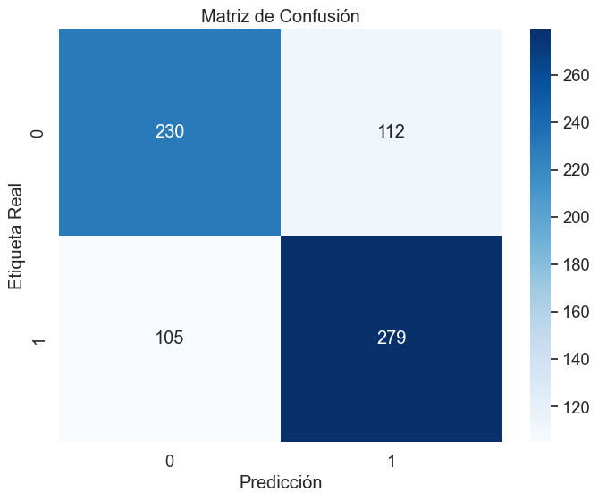

```python
def plot_confusion_matrix(modelo, data_loader):
    class_names = ['0', '1']
    y_true = []
    y_pred = []
    modelo.eval()

    with torch.no_grad():
        for images, labels in data_loader:
            images, labels = images.to(device), labels.to(device)
            outputs = modelo(images)
            predicted = (torch.sigmoid(outputs) > 0.5).float()
            y_true.extend(labels.cpu().numpy())
            y_pred.extend(predicted.cpu().numpy())

    # Calcular la matriz de confusión
    confusion = confusion_matrix(y_true, y_pred)
    plt.figure(figsize=(8, 6))
    sns.set(font_scale=1.2)  # Ajusta el tamaño de fuente para que sea legible
    sns.heatmap(confusion, annot=True, fmt="d", cmap="Blues", xticklabels=class_names, yticklabels=class_names)
    plt.xlabel("Predicción")
    plt.ylabel("Etiqueta Real")
    plt.title("Matriz de Confusión")
    plt.show()

plot_confusion_matrix(modelo, test_loader)
```

### Feature visualization

Para aplicar la técnica de feature visualization, primero se guardan las capas convolucionales son sus respectivos pesos calculados durante el entrenamiento

```python
model_weights =[]
conv_layers = []
model_children = list(modelo.children())
counter = 0
for i in range(len(model_children)):
    if type(model_children[i]) == nn.Conv2d:
        counter+=1
        model_weights.append(model_children[i].weight)
        conv_layers.append(model_children[i])
    elif type(model_children[i]) == nn.Sequential:
        for j in range(len(model_children[i])):
            for child in model_children[i][j].children():
                if type(child) == nn.Conv2d:
                    counter+=1
                    model_weights.append(child.weight)
                    conv_layers.append(child)
print(f"Total convolution layers: {counter}")
print(conv_layers)
```

```
Total convolution layers: 3
[Conv2d(1, 32, kernel_size=(3, 3), stride=(1, 1), padding=(1, 1)), Conv2d(32, 64, kernel_size=(3, 3), stride=(1, 1), padding=(1, 1)), Conv2d(64, 128, kernel_size=(3, 3), stride=(1, 1), padding=(1, 1))]
```

A la siguiente imagen de prueba se le aplicarán los filtros convolucionales entrenados en la red neuronal para identificar el espacio latente de características resultantes al aplicarle las respectivas convoluciones

```
(-0.5, 511.5, 511.5, -0.5)
```

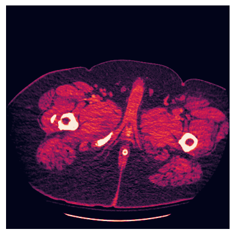

```python
image = Image.open(str('images_1/33.png'))
plt.imshow(image)
plt.axis('off')
```

Se pasa la imagen por el transformador (canales a grises, re dimensionamiento, conversión a tensor, y normalización), y se aplican las 3 capas convolucionales para posteriormente guardar los vectores resultantes en un arreglo de valores que posteriormente serán graficados

```python
image = transform(image)
print(f"Image shape before: {image.shape}")
image = image.unsqueeze(0)
print(f"Image shape after: {image.shape}")
image = image.to(device)

outputs = []
names = []
processed = []
for layer in conv_layers[0:]:
    image = layer(image)
    outputs.append(image)
    names.append(str(layer))
print(len(outputs))
for feature_map in outputs:
    print(feature_map.shape)
for feature_map in outputs:
    feature_map = feature_map.squeeze(0)
    gray_scale = torch.sum(feature_map,0)
    gray_scale = gray_scale / feature_map.shape[0]
    processed.append(gray_scale.data.cpu().numpy())
```

[output not shown]

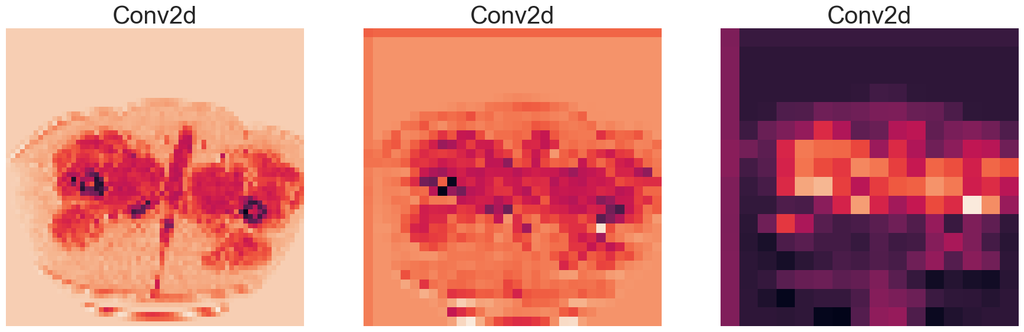

```python
fig = plt.figure(figsize=(30, 50))
for i in range(len(processed)):
    a = fig.add_subplot(5, 4, i+1)
    imgplot = plt.imshow(processed[i])
    a.axis("off")
    a.set_title(names[i].split('(')[0], fontsize=30)
plt.savefig(str('feature_maps.jpg'), bbox_inches='tight')
```

### Transfer Learning

Del repositorio de modelos de torchvision se importa la red convolucional entrada vgg19, la cual es una red muy profunda entrada con con 19 capas ocultas (16 convolucionales y 3 fully connected) y entrada con cientos de miles de imagenes de distintos objetos para una tarea de clasificación muticlase.

Esta red será tuneada para la tarea de clasificación de traumas abdominales, aprovechando toda su capacidad de extracción de características con sus filtros convolucionales ya entrenados, simplemente haciendo una modificación en la capa de entrada para que reciba imagenes de un solo canal de color y en la capa de salida para que genere una clasificación binaria

```python
from torchvision import models
model = models.vgg19(pretrained=True)
```

Estrcutura de la red neuronal vgg19

```python
model
```

```
VGG(
  (features): Sequential(
    (0): Conv2d(3, 64, kernel_size=(3, 3), stride=(1, 1), padding=(1, 1))
    (1): ReLU(inplace=True)
    (2): Conv2d(64, 64, kernel_size=(3, 3), stride=(1, 1), padding=(1, 1))
    (3): ReLU(inplace=True)
    (4): MaxPool2d(kernel_size=2, stride=2, padding=0, dilation=1, ceil_mode=False)
    (5): Conv2d(64, 128, kernel_size=(3, 3), stride=(1, 1), padding=(1, 1))
    (6): ReLU(inplace=True)
    (7): Conv2d(128, 128, kernel_size=(3, 3), stride=(1, 1), padding=(1, 1))
    (8): ReLU(inplace=True)
    (9): MaxPool2d(kernel_size=2, stride=2, padding=0, dilation=1, ceil_mode=False)
    (10): Conv2d(128, 256, kernel_size=(3, 3), stride=(1, 1), padding=(1, 1))
    (11): ReLU(inplace=True)
    (12): Conv2d(256, 256, kernel_size=(3, 3), stride=(1, 1), padding=(1, 1))
    (13): ReLU(inplace=True)
    (14): Conv2d(256, 256, kernel_size=(3, 3), stride=(1, 1), padding=(1, 1))
    (15): ReLU(inplace=True)
    (16): Conv2d(256, 256, kernel_size=(3, 3), stride=(1, 1), padding=(1, 1))
    (17): ReLU(inplace=True)
    (18): MaxPool2d(kernel_size=2, stride=2, padding=0, dilation=1, ceil_mode=False)
    (19): Conv2d(256, 512, kernel_size=(3, 3), stride=(1, 1), padding=(1, 1))
    (20): ReLU(inplace=True)
    (21): Conv2d(512, 512, kernel_size=(3, 3), stride=(1, 1), padding=(1, 1))
    (22): ReLU(inplace=True)
    (23): Conv2d(512, 512, kernel_size=(3, 3), stride=(1, 1), padding=(1, 1))
    (24): ReLU(inplace=True)
    (25): Conv2d(512, 512, kernel_size=(3, 3), stride=(1, 1), padding=(1, 1))
    (26): ReLU(inplace=True)
    (27): MaxPool2d(kernel_size=2, stride=2, padding=0, dilation=1, ceil_mode=False)
    (28): Conv2d(512, 512, kernel_size=(3, 3), stride=(1, 1), padding=(1, 1))
    (29): ReLU(inplace=True)
    (30): Conv2d(512, 512, kernel_size=(3, 3), stride=(1, 1), padding=(1, 1))
    (31): ReLU(inplace=True)
    (32): Conv2d(512, 512, kernel_size=(3, 3), stride=(1, 1), padding=(1, 1))
    (33): ReLU(inplace=True)
    (34): Conv2d(512, 512, kernel_size=(3, 3), stride=(1, 1), padding=(1, 1))
    (35): ReLU(inplace=True)
    (36): MaxPool2d(kernel_size=2, stride=2, padding=0, dilation=1, ceil_mode=False)
  )
  (avgpool): AdaptiveAvgPool2d(output_size=(7, 7))
  (classifier): Sequential(
    (0): Linear(in_features=25088, out_features=4096, bias=True)
    (1): ReLU(inplace=True)
    (2): Dropout(p=0.5, inplace=False)
    (3): Linear(in_features=4096, out_features=4096, bias=True)
    (4): ReLU(inplace=True)
    (5): Dropout(p=0.5, inplace=False)
    (6): Linear(in_features=4096, out_features=1000, bias=True)
  )
)
```

A continuación se realiza la cutomización de la red neuronal vgg19 modificándose su capa de entrada para que reciba imagenes en escala de grises y su última capa para que genere resultados binarios como output

```python
for param in model.parameters():
    param.requires_grad = False
```

```python
model.features[0] = nn.Conv2d(1, 64, kernel_size=3, padding=1)
```

```python
for param in model.features[0].parameters():
    param.requires_grad = False
```

```python
model.classifier[-1] = nn.Sequential(
                      nn.Linear(4096, 260),
                      nn.ReLU(),
                      nn.Dropout(0.4),
                      nn.Linear(260, 1))
```

```python
model = model.to(device)
```

```python
num_epochs = 20
for epoch in range(num_epochs):
  model.train()
  total_loss = 0.0
  for data, targets in train_loader:
    data = data.to(device)
    targets = targets.to(device)
    optimizador.zero_grad()
    out = model(data)
    loss = criterio(out, targets.unsqueeze(1))
    loss.backward()
    optimizador.step()
    total_loss += loss.item()

print('Training finished')
```

```
Training finished
```

A esta red neuronal se le aplica el mismo procedimiento para hacer el transfer learning, a esta red es necesario modificar las capas fully connected del final para modificar el resultado de la salida y la capa de entrada para que reciba imagenes con un solo canal de color

```python
from torchvision import models
chexnet = models.densenet121(pretrained=True)
```

Modificación de la capa lineal con una sola neurona a la salida de acuerdo a nuestra tarea de clasificación binaria

```python
chexnet.classifier = nn.Sequential(
    nn.Linear(1024, 1),
    nn.Sigmoid()
)
```

Modificación de la capa de entrada para que reciba imagenes con un solo canal de color

```python
chexnet.features[0] = nn.Conv2d(1, 64, kernel_size=7, stride=2, padding=3, bias=False)
```

```python
modelo = chexnet.to(device)
```

Entrenamiento y validación del modelo

```python
num_epochs = 10
for epoch in range(num_epochs):
  model.train()
  total_loss = 0.0
  for data, targets in train_loader:
    data = data.to(device)
    targets = targets.to(device)
    optimizador.zero_grad()
    out = model(data)
    loss = criterio(out, targets.unsqueeze(1))
    loss.backward()
    optimizador.step()
    total_loss += loss.item()

    print(f"Epoch {epoch+1}/{num_epochs}, Loss: {total_loss/len(train_loader)}")

print('Training finished')
```

[output not shown]

```python
model.eval()
total_correct = 0
total_samples = 0
with torch.no_grad():
    for data, targets in test_loader:
        data = data.to(device)
        targets = targets.to(device)
        outputs = model(data)
        targets = targets.unsqueeze(1).float()
        predictions = (outputs > 0.5).float()
        correct = (predictions == targets).sum().item()
        total_correct += correct
        total_samples += targets.size(0)

# Calcular la precisión en el conjunto de prueba
accuracy = (total_correct / total_samples) * 100.0
print(f'Accuracy on test set: {accuracy:.2f}%')
```

```
Accuracy on test set: 64.88%
```

## Inferencia

El siguiente codigo prueba el modelo entrenado y guardado

```
Prediction: No Trauma
```

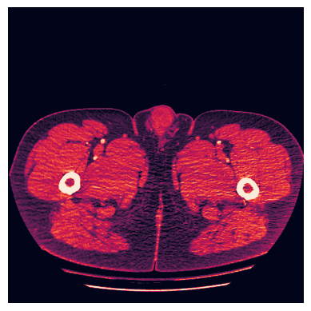

```python
modelo = CNN().to(device)
modelo.load_state_dict(torch.load('modelo.pth'))
modelo.eval()

def predict_image(image_path):
    image = Image.open(image_path)
    image_tensor = transform(image).unsqueeze(0)
    image_tensor = image_tensor.to(device)

    with torch.no_grad():
        output = modelo(image_tensor)
        predicted_class = torch.argmax(output).item()

    return predicted_class

image_path = 'images_0/19.png'
predicted_class = predict_image(image_path)
result = "No Trauma" if predicted_class == 0 else "Trauma"
plt.imshow(Image.open(image_path))
plt.axis("off")
print('Prediction:', result)
```